# A Simple Analysis of UFC on Fox Viewership

Data retrieved from:

Viewer/Ratings Numbers from [mmapayout](http://mmapayout.com/2014/04/ufc-on-fox-11-overnight-rating-1-99m-viewers/)

Event Names from [wikipedia](http://en.wikipedia.org/wiki/UFC_on_Fox)

## Preparation

First we have to load the data and massage it a little to make it easier to work with:

```r
library(lubridate)
library(ggplot2)
library(gtools)
library(forecast)
library(plyr)

ratings <- read.csv("ratings.csv")
ratings$id <- 1:nrow(ratings)
ratings$date <- as.Date(ratings$date)
ratings$overall_viewers_quartiles <- as.numeric(quantcut(ratings$viewers))
# ratings$rating_quartiles <- as.numeric(quantcut(ratings$rating))
ratings$quarters <- quarters(as.Date(ratings$date))
ratings$month <- month(as.Date(ratings$date))
ratings$year <- year(as.Date(ratings$date))

ratings <- merge(ratings, ddply(ratings, "quarters", summarize, quarters.viewers = sum(viewers)),
    by = "quarters")

ratings <- ratings[with(ratings, order(id)), ]

ufc_ratings <- subset(ratings, promotion == "ufc")
ufc_ratings$viewers_quartiles <- as.numeric(quantcut(ufc_ratings$viewers))
ufc_ratings <- ufc_ratings[with(ufc_ratings, order(id)), ]
```

# UFC Ratings

Let's just get a raw summary of viewership data:

```r
summary(ufc_ratings$viewers)
```

```
##    Min. 1st Qu.  Median    Mean 3rd Qu.    Max.
##    1.99    2.43    3.22    3.45    4.31    5.70
```

This is what it looks like when we plot viership by date, add a loess smoothed fit, and color code based on quartile:

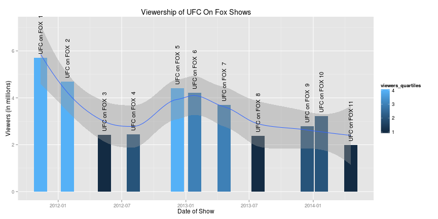

```r
ggplot(ufc_ratings, aes(x = date, y = viewers)) + geom_histogram(aes(fill = viewers_quartiles),
    stat = "identity") + geom_smooth(method = "loess") + geom_text(aes(label = show),
    angle = 90, hjust = -0.05, size = 4) + ylab("Viewers (in millions)") + xlab("Date of Show") +
    ggtitle("Viewership of UFC On Fox Shows")
```

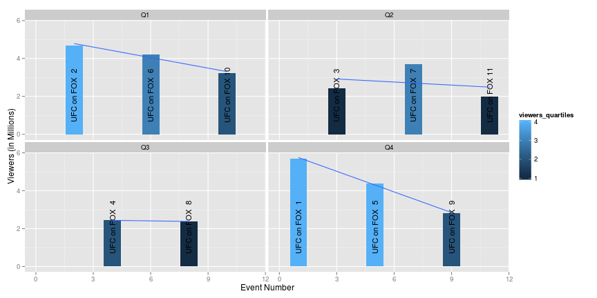

```r
ggplot(ufc_ratings, aes(x = id, y = viewers, xmin = 0)) + geom_histogram(aes(fill = viewers_quartiles),
    stat = "identity") + facet_wrap(~quarters) + geom_text(aes(label = show,
    y = 2), angle = 90, size = 4) + geom_smooth(method = "lm", se = FALSE) +
    xlab("Event Number") + ylab("Viewers (in Millions)")
```

This shows that there definitely was a level of seasonality during the first few offerings of the UFC on Fox, however the seasonal potential bump has been leveled. This could be caused by a number of interesting socialogical reasons, my personal guess is that the seasonal bump has leveled due to hardcores innability to re-convince their families that tuning in was a worthwhile endeavor. If you will the “newness” has worn off.

If we stack them up by quarter, how obvious is the trend?

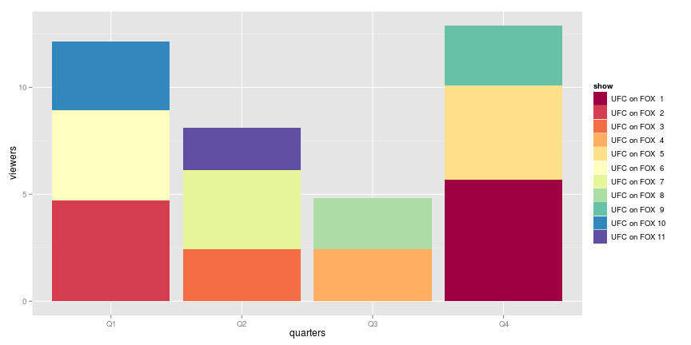

```r
ggplot(ufc_ratings, aes(x = quarters, y = viewers)) + geom_histogram(aes(fill = show),
    stat = "identity") + scale_fill_brewer(palette = "Spectral")
```

While the 4th quarter (the end of the year show) is still the king, it will be interesting to see if the stacked segments continue to grow smaller the higher up we go up the chart.

The bubble plot definitely shows a clear trend when we graph across the full timeline:

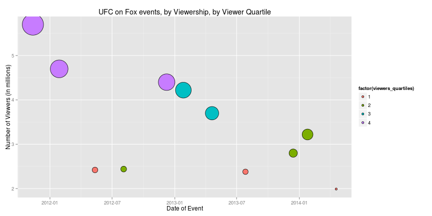

```r
ggplot(ufc_ratings, aes(x = date, y = viewers, size = viewers)) + geom_point(aes(fill = factor(viewers_quartiles)),
    guide = FALSE, shape = 21) + scale_size(trans = "log2", range = c(2, 20)) +
    guides(size = FALSE) + xlab("Date of Event") + ylab("Number of Viewers (in millions)") +
    ggtitle("UFC on Fox events, by Viewership, by Viewer Quartile")
```

Bigger bubbles at the top left show us that when we started, there was definitely buzz and promise to the UFC on Fox shows, buht a clear downward trend as we get closer to current day is clear, including the same effect of coloring by quartile.

If we break it down by year, it gets even more brutal:

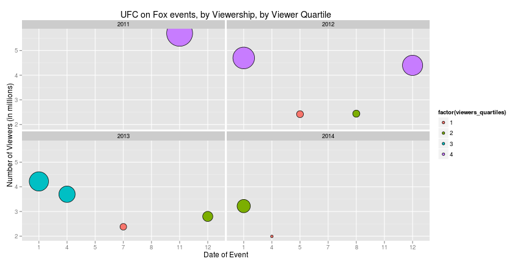

```r
ggplot(ufc_ratings, aes(x = factor(month), y = viewers, size = viewers)) + geom_point(aes(fill = factor(viewers_quartiles)),
    guide = FALSE, shape = 21) + scale_size(trans = "log2", range = c(2, 20)) +
    guides(size = FALSE) + xlab("Date of Event") + ylab("Number of Viewers (in millions)") +
    ggtitle("UFC on Fox events, by Viewership, by Viewer Quartile") + facet_wrap(~year)
```

There is no question that as the years pass, the height and size of the bubbles is shrinking.

So, let's use some fun tools, let's use the forecast package. It's not a good sign when the forecast package actually predicts values below zero:

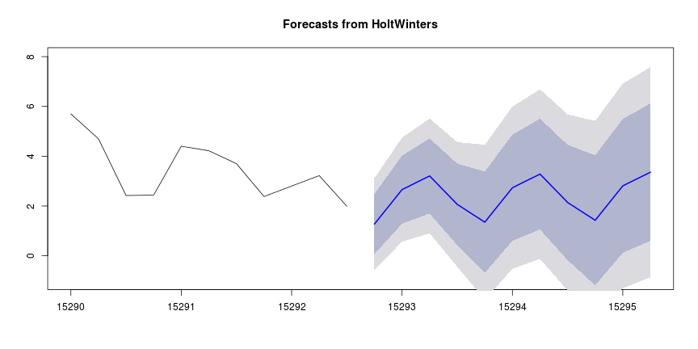

```r
myts <- ts(ufc_ratings$viewers, frequency = 4, start = min(ufc_ratings$date))

fit <- HoltWinters(myts)
preds <- forecast(fit, nrow(ufc_ratings))
plot(preds, ylim = c(-1, 8))
```

The forecast takes into account some level of seasonality, and of course any number of interventions by Zuffa management and Fox can change this, but a simple numerical forecast shows that the current trends leave most of the probability of viewership pretty unchanged. The question is will FOX stop airing if ratings hit the lower bound of the probability distribution of the forecast.

# Bellator Ratings

For fun, I collected the data for the Bellator events during the same time period. Let's see what that data looks like!

```r
bellator_ratings <- subset(ratings, promotion == "bellator")
bellator_ratings$viewers_quartiles <- as.numeric(quantcut(bellator_ratings$viewers))
bellator_ratings <- bellator_ratings[with(bellator_ratings, order(id)), ]
```

Let's just get a raw summary of viewership data:

```r
summary(bellator_ratings$viewers)
```

```
##    Min. 1st Qu.  Median    Mean 3rd Qu.    Max.
##   0.105   0.167   0.520   0.476   0.718   1.100
```

This is what it looks like when we plot viership by date, add a loess smoothed fit, and color code based on quartile:

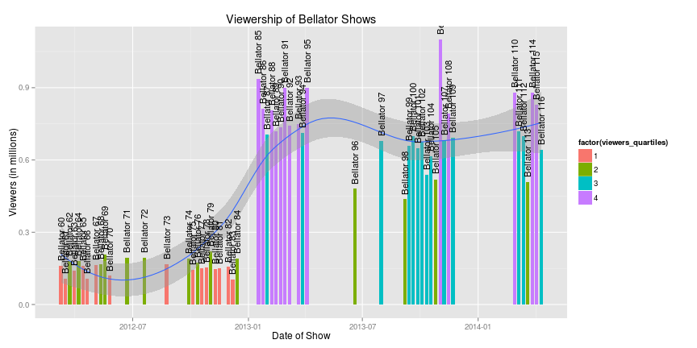

```r
ggplot(bellator_ratings, aes(x = date, y = viewers)) + geom_histogram(aes(fill = factor(viewers_quartiles)),
    stat = "identity") + geom_smooth(method = "loess") + geom_text(aes(label = show),
    angle = 90, hjust = -0.05, size = 4) + ylab("Viewers (in millions)") + xlab("Date of Show") +
    ggtitle("Viewership of Bellator Shows")
```

But there's something really obvious happening here, what's the difference between the first part of the graph, and the second part?

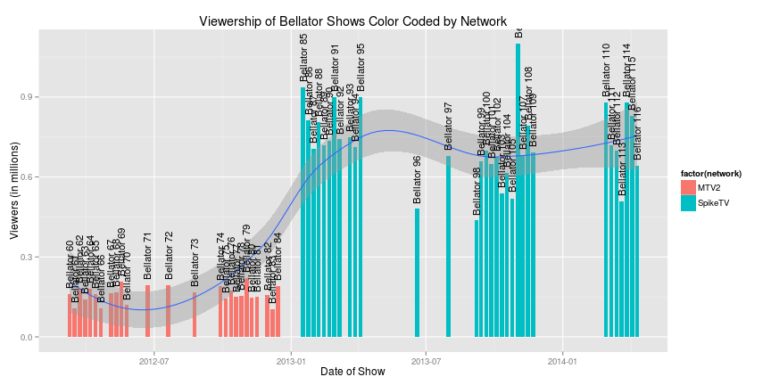

```r
ggplot(bellator_ratings, aes(x = date, y = viewers)) + geom_histogram(aes(fill = factor(network)),
    stat = "identity") + geom_smooth(method = "loess") + geom_text(aes(label = show),
    angle = 90, hjust = -0.05, size = 4) + ylab("Viewers (in millions)") + xlab("Date of Show") +
    ggtitle("Viewership of Bellator Shows Color Coded by Network")
```

Bellator's Switch to SpikeTV in 2013 saw a serious change in the audience reach!

People sure do love bubble plots, and the UFC one showed a pretty clear declining trend. Let's do the same thing for the Bellator Viewership Data:

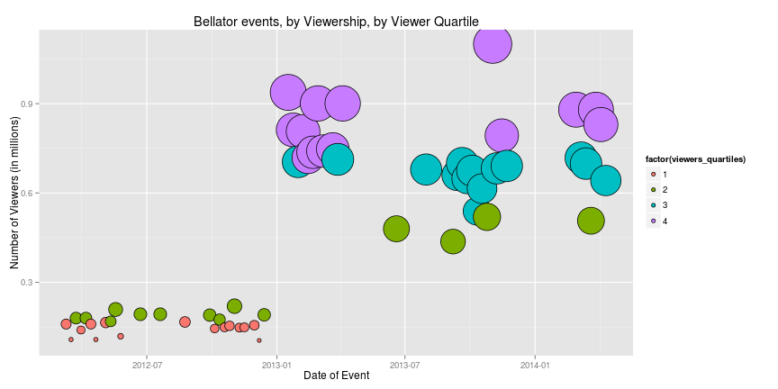

```r
ggplot(bellator_ratings, aes(x = date, y = viewers, size = viewers)) + geom_point(aes(fill = factor(viewers_quartiles)),
    guide = FALSE, shape = 21) + scale_size(trans = "log2", range = c(2, 20)) +
    guides(size = FALSE) + xlab("Date of Event") + ylab("Number of Viewers (in millions)") +
    ggtitle("Bellator events, by Viewership, by Viewer Quartile")
```

Same thing with the forecast package! What's Bellator's Current Trend?

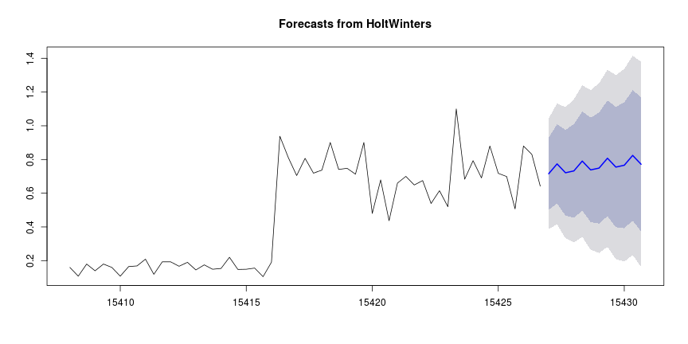

```r
myts <- ts(bellator_ratings$viewers, frequency = 3, start = min(bellator_ratings$date))

fit <- HoltWinters(myts)
preds <- forecast(fit, 12)
plot(preds)
```

I don't know that I trust this data, the frequency data is hard to do for events.

# Joint Data

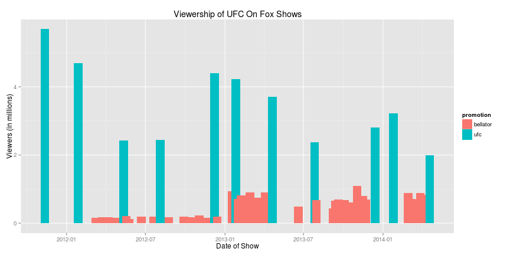

```r
ggplot(ratings, aes(x = date, y = viewers)) + geom_histogram(aes(fill = promotion),
    width = 20, stat = "identity") + ylab("Viewers (in millions)") + xlab("Date of Show") +
    ggtitle("Viewership of UFC On Fox Shows")
```

It's clear that Bellator's individual ratings are noise, they just crawl along the bottom of the line. But how doe it look when we aggregate it?

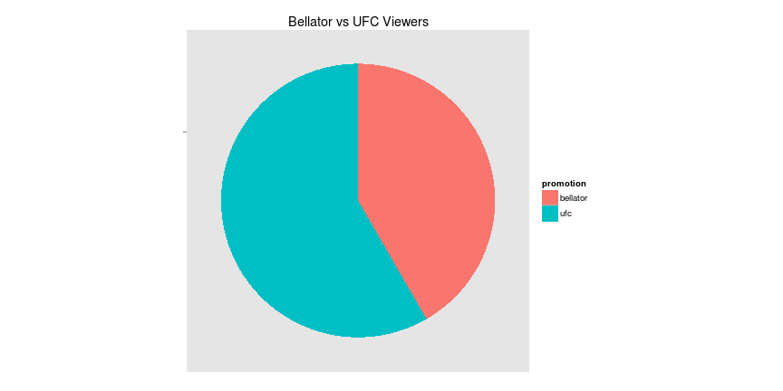

```r
ggplot(ratings, aes(x = factor(1), weight = viewers, fill = promotion)) + geom_bar(width = 1) +
    coord_polar(theta = "y") + theme(axis.title.x = element_blank(), axis.title.y = element_blank(),
    axis.text.x = element_blank(), axis.text.y = element_blank(), panel.grid.minor = element_blank(),
    panel.grid.major = element_blank(), panel.border = element_blank()) + ggtitle("Bellator vs UFC Viewers")
```

So, the UFC is still clearly in the ratings lead, since this is just “on Fox” events vs all Bellator events.

TODO:

- Add variables for the “draw” value of main and co-main event
- Find data set for bellator during this same time period
- Find data set for PPV data to overlay
- Get someone to contribute to this :)